# Cirugía Torácica

Published

September 30, 2024

## 1 Importación y Depuración de Datos

|  | servicio | columna1 | fecha | h_ini | h_fin | prolong | quirofano | anul | tipo_int | tipo_cirug | cama | anestesia | columna2 | a_postqui | implante | parto | exitus | reinterv | multiple | rx | bio_intra | ana_pat | muestr | hemoderv | rec_gasas | profilax | gr_sang | intensif | foto | … |
| --- | --- | --- | --- | --- | --- | --- | --- | --- | --- | --- | --- | --- | --- | --- | --- | --- | --- | --- | --- | --- | --- | --- | --- | --- | --- | --- | --- | --- | --- | --- |
| 1 | CIR TORACICA |  | 18/03/2024 | 16:58 | 22:35 | S | QMF20 |  | PROGRAMADA | CONTAMINADA | G415-2 | GENERAL |  | REANIMACION | N | N | N |  | N | N | N | S | 5 | HEM 1 | N | S | N | N | N | … |
| 2 | CIR TORACICA |  | 26/06/2024 | 20:30 | 22:25 | N | QMF20 |  | URGENTE | LIMPIA | G403-2 | GENERAL |  | DESPERTAR | N | N | N | N | N | N | N | S | 2 |  | N | S | N | N | N | … |
| 3 | CIR TORACICA |  | 09/04/2024 | 18:26 | 22:15 | N | QMF20 |  | URGENTE | LIMPIA | G425-1 | GENERAL |  | DESPERTAR | N | N | N | N | N | N | N | S | 2 |  | N | N | N | N | N | … |
| 4 | CIR TORACICA |  | 28/02/2024 | 16:40 | 21:30 | N | QMF20 |  | PROGRAMADA | CONTAMINADA | G405-2 | GENERAL |  | REANIMACION | N | N | N |  | N | N | N | S | 4 |  | N | S | N | N | N | … |
| 5 | CIR TORACICA |  | 18/08/2024 | 18:50 | 21:20 | N | QMF11 |  | URGENTE | CONTAMINADA | GUK-06 | GENERAL |  | UCI | N | N | N | N | N | N | N | S | 2 |  | N | N | N | N | N | … |

- `fecha`: modificación del tipo de dato para manejarlo como una fecha.
- `h_ini` (hora de inicio de la cirugía concatenación `fecha` y `h_ini`
- `h_fin` (hora de finalización de la cirugía): concatenación `fecha` y `h_fin`
- `h_15`: creramos esta variable que representa las 15:00 horas del día que indica la variable `fecha`
- `tiempo_quirurgico` (minutos): variable de nueva creación resultado de `h_fin` - `h_ini`
- `fin_posterior_15`(TRUE vs FALSE): variable de nueva creación. TRUE si la cirugía termina después de las 15:00 horas.
- `prolong`: variable `prolongación` tal y como se registra es recodificada como TRUE/FALSE.
- `prolong2`: nueva variable que registra las prolongaciones de acuerdo con información ofrecida por SSQQ (variable ya importada desde archivo .xls que es transformada a formato lógico TRUE/FALSE)

|  | fecha | h_ini | h_fin | h_15 | tiempo_quirurgico | fin_posterior_15 |
| --- | --- | --- | --- | --- | --- | --- |
| 1 | 2024-01-02 | 2024-01-02T09:20:00Z | 2024-01-02T16:20:00Z | 2024-01-02T15:00:00Z | 420 | True |
| 2 | 2024-01-02 | 2024-01-02T08:00:00Z | 2024-01-02T08:00:00Z | 2024-01-02T15:00:00Z | 0 | False |
| 3 | 2024-01-04 | 2024-01-04T11:55:00Z | 2024-01-04T14:00:00Z | 2024-01-04T15:00:00Z | 125 | False |
| 4 | 2024-01-04 | 2024-01-04T08:35:00Z | 2024-01-04T11:25:00Z | 2024-01-04T15:00:00Z | 170 | False |
| 5 | 2024-01-04 | 2024-01-04T08:00:00Z | 2024-01-04T08:00:00Z | 2024-01-04T15:00:00Z | 0 | False |

- Conversion de la variable `anul` a variable tipo lógico (TRUE vs FALSE)
- Creación de la variable `lobectomia` como procedimiento mayor más representativo que se utilizará para el cálculo del tiempo quirúrgico estandard en procedimientos mayores. La creación de dicha variable se realizado a partir de expresiones regulares en combinación con el tiempo quirúrgico y el área postquirúrgica requerida:

|  | procedimientos | a_postqui | tiempo_quirurgico | lobectomia |
| --- | --- | --- | --- | --- |
| 1 | LID VATS | REANIMACION | 337 | True |
| 2 | VIDEOTORACOSCOPIA EXPLORADORA IZD | DESPERTAR | 115 | False |
| 3 | DESBRIDAMIENTO VAC DCHO | DESPERTAR | 229 | False |
| 4 | LOBECTOMIA LSI X VATS IZDA + | REANIMACION | 290 | True |
| 5 | TGORACOTOMIA DERECHA + DRENAJE | UCI | 150 | False |
| 6 | DESBRIDAMIENTO POR VATS | DESPERTAR | 175 | False |
| 7 | DECORTICACION | DESPERTAR | 285 | False |
| 8 | DRENAJE+SUTURA DIAFRAGMATICA | UCI | 100 | False |
| 9 | LOBECTOMIA LID X VATS +TORACOTOMIA | REANIMACION | 335 | True |
| 10 | RAVITCH | DESPERTAR | 245 | False |

[output cut: 368 more lines]

- Creación de la variable `cirujano` representando el cirujano principal del procedimiento. Dicho profesional se obtiene extrayendo el primer profesional de la lista de cirujanos de la tabla original.

|  | cirujanos | cirujano_pral |
| --- | --- | --- |
| 1 | ORDOÑEZ LOZANO, P. (Pral); MUÑOZ GONZALEZ, N.; DIAZ SANZ, B.; | ORDOÑEZ LOZANO, P. |
| 2 | ORDOÑEZ LOZANO, P. (Pral); REY GUTAMA, R.; | ORDOÑEZ LOZANO, P. |
| 3 | ROYO CRESPO, I. (Pral); BRAVO MENDOZA, M.; EMBUN FLOR, R.; | ROYO CRESPO, I. |
| 4 | ORDOÑEZ LOZANO, P. (Pral); MARTINEZ VALLINA, P.; GARCIA RODRIGUEZ, O.; | ORDOÑEZ LOZANO, P. |
| 5 | ORDOÑEZ LOZANO, P. (Pral); ALVAREZ GOMEZ, J.; RECUERO DIAZ, J.; | ORDOÑEZ LOZANO, P. |

## 2 Procedimientos Mensuales

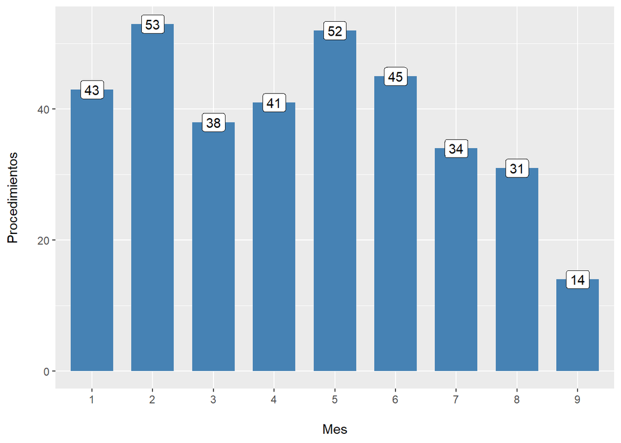

## 3 Jornadas de Mañana (JM)

### 3.1 Tiempo Quirúrgico Útil JM

- Aquellas jornadas quirúrgicas en las que existe un procedimiento cuya duración registrada es de 0 minutos son excluidas para el computo del tiempo quirúrgico útil.

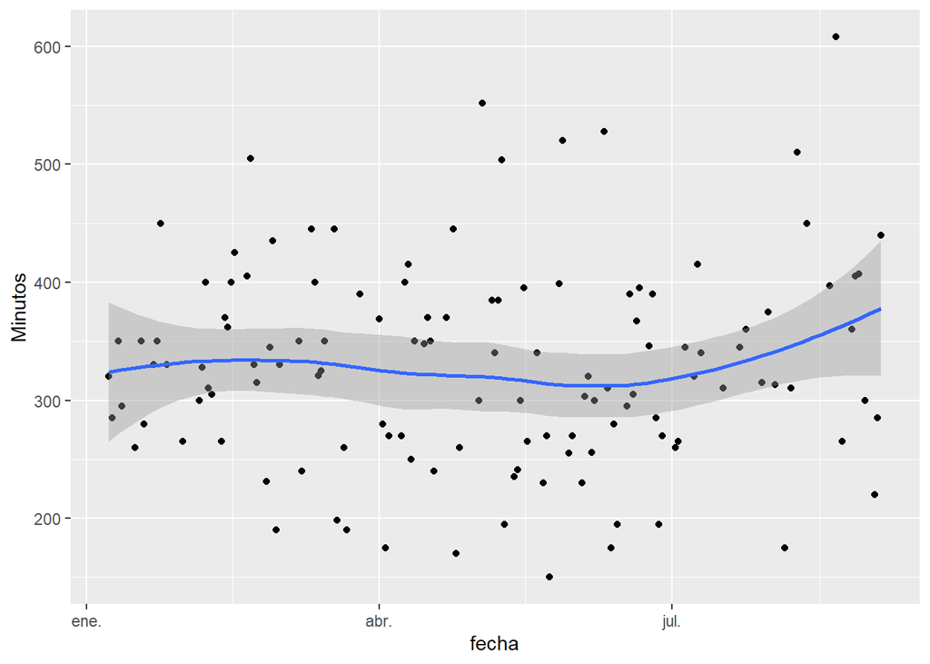

### 3.2 Tiempo de Finalización (JM)

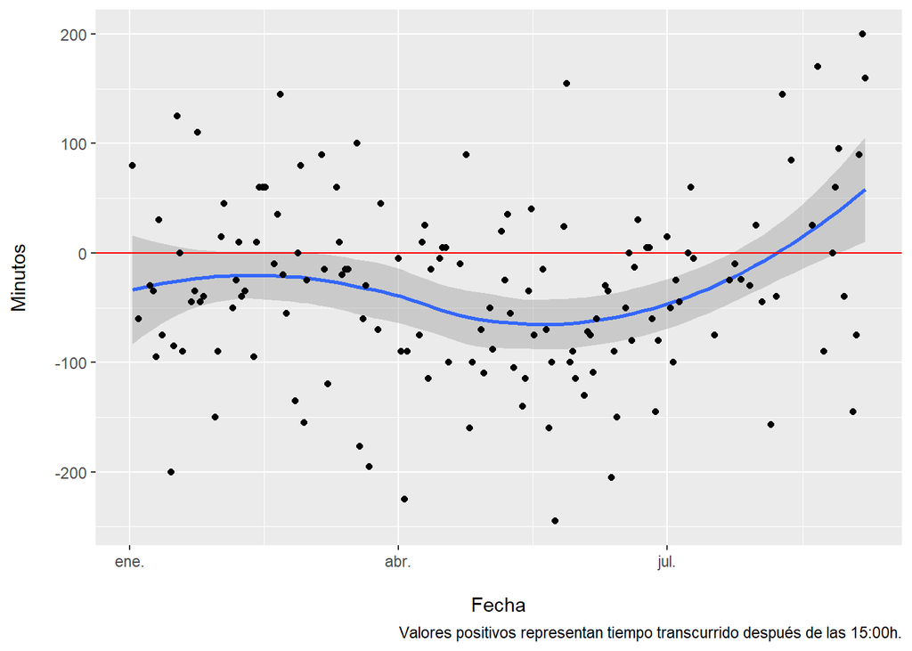

## 4 Cancelaciones / Mes

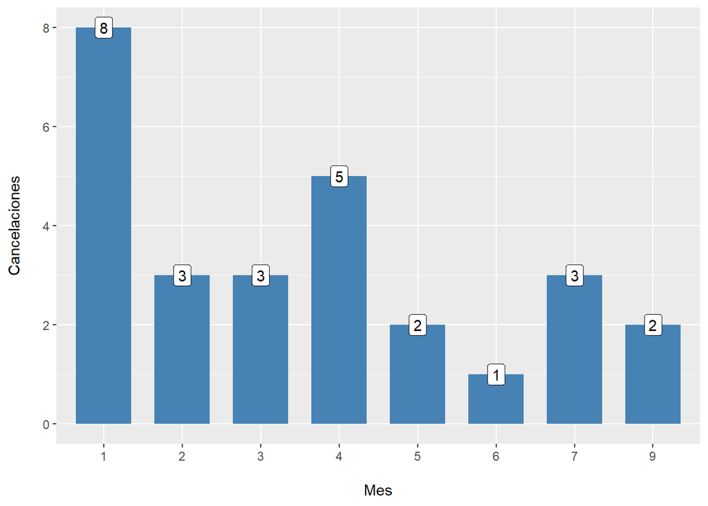

## 5 Hora de Cancelación

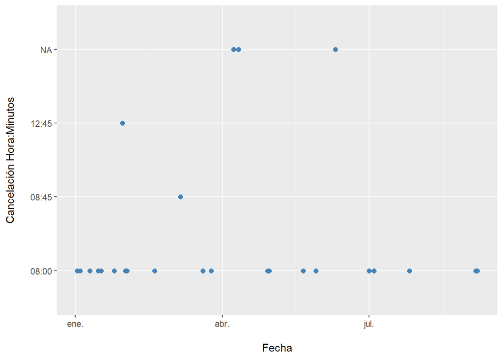

## 6 Jornadas Continuas (JC), Prolongaciones (P) y Excesos de Jornada (EJ)

### 6.1 Mensuales (incluida Robótica)

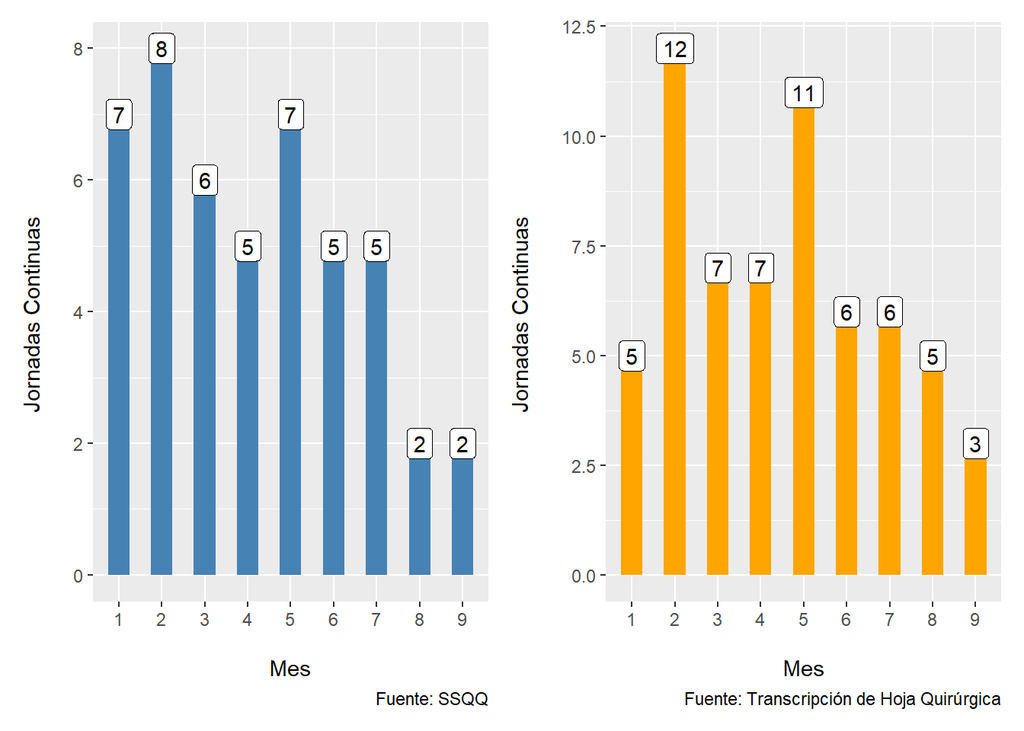

### 6.2 Procedimientos diarios en JC, Prolongación o Exceso-Jornada

- En este gráfico se representan el número de procedimientos quirúrgicos mensuales realizados en días con o sin prolongación de jornada para cada tipo de fuente: SSQQ vs Transcripción Hoja Quirúrgica.

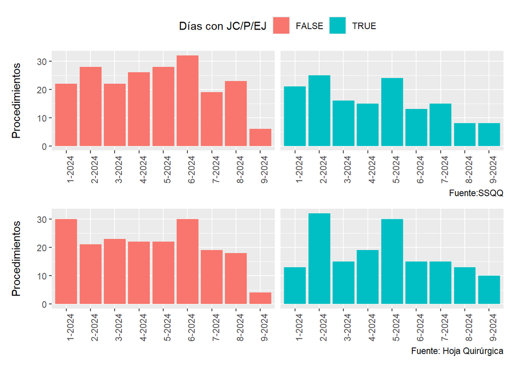

### 6.3 Finalización de JC/P/EJ

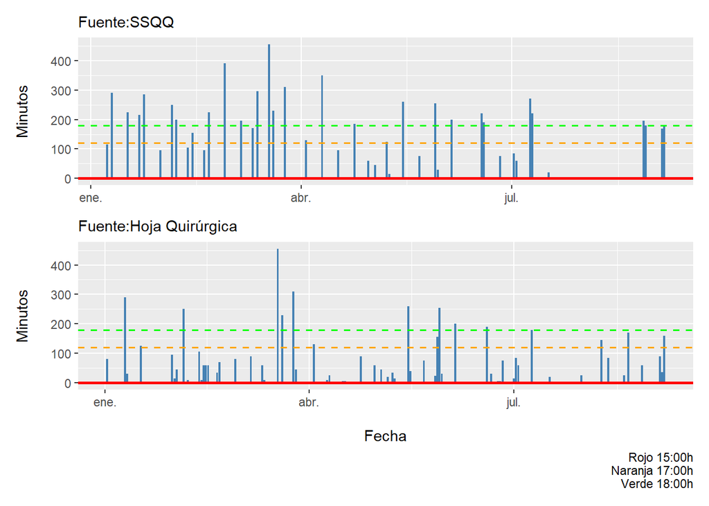

## 7 Cirugía Robótica

- Creamos la variable `robot`a partir de los registros con sombreado naranja.

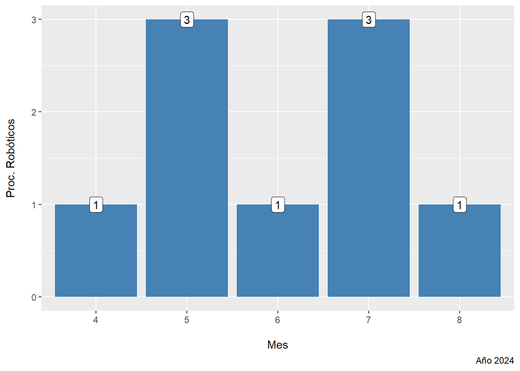

## 8 Cirugía Urgente

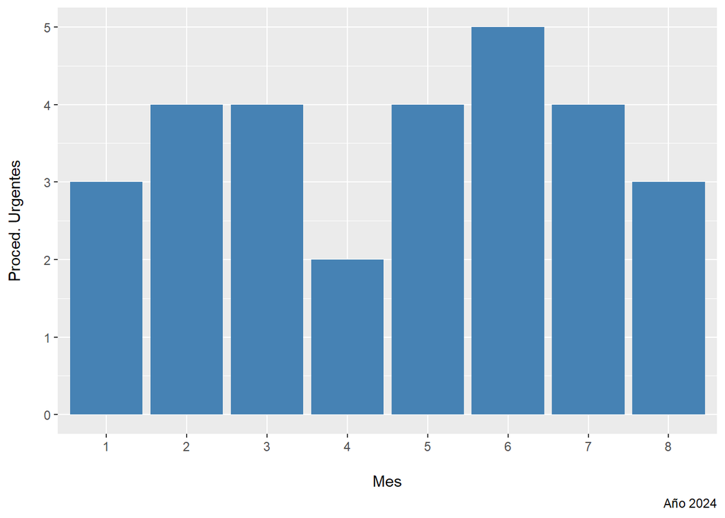

## 9 Tiempo Quirúrgico Standard (Lobectomía)

|  | Mes | mean | median | p40 | p60 |
| --- | --- | --- | --- | --- | --- |
| 1 | 1 | 262 | 245 | 219 | 262 |
| 2 | 2 | 258 | 255 | 237 | 260 |
| 3 | 3 | 266 | 255 | 245 | 265 |
| 4 | 4 | 272 | 255 | 230 | 271 |
| 5 | 5 | 266 | 250 | 240 | 270 |
| 6 | 6 | 261 | 256 | 235 | 256 |
| 7 | 7 | 303 | 290 | 278 | 296 |
| 8 | 8 | 284 | 246 | 240 | 252 |
| 9 | 9 | 315 | 270 | 260 | 330.4 |

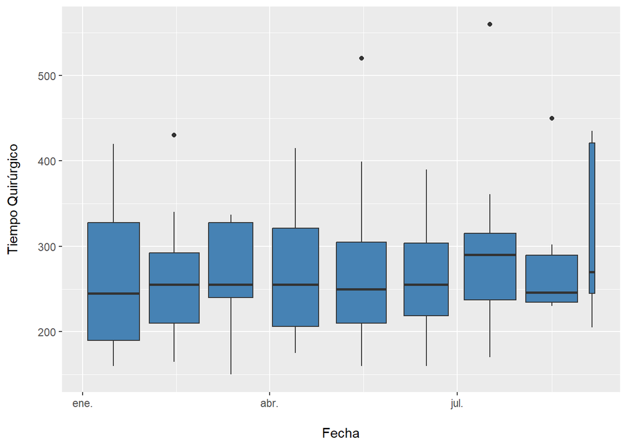